# SI538_prc_analysis_Rnotebook

Samantha Ryan-Lee

12/11/2020

## Residential Feedback Survey Analysis

```r
library(knitr)
library(tidyverse)
```

```r
library(ggplot2)
library(dplyr)
library(readxl)
library(skimr)
library(moderndive)
library(infer)
library(pwr)
prc_survey_wlist <- read.csv("F:/UMSI Fall 2020/courses/SI538/project_materials/recorded_responses_wlists.csv")
#prc_survey_wlist
```

```r
tot_resps <- prc_survey_wlist %>% summarize(total = n())
tot_resps
```

```
##   total
## 1   540
```

```r
rc_situations <- read.csv("F:/UMSI Fall 2020/courses/SI538/project_materials/recycling_situations.csv")
#rc_situations
```

```r
info_relationships <- read.csv("F:/UMSI Fall 2020/courses/SI538/project_materials/info_relationships_df.csv")
#info_relationships
```

# Contamintaion History

```r
contam_hx <- read.csv("F:/UMSI Fall 2020/courses/SI538/project_materials/lansing_contamination_history - 2017.csv")
#contam_hx
estimated_contam_hx <- contam_hx %>%
  filter(year == "2019" | year == "2020") %>%
  mutate(estimated_contamination_occ = contamination_occ*3)
complete_contam_hx <- merge(estimated_contam_hx, contam_hx)
#complete_contam_hx
```

```r
contam_hx2 <- read.csv("F:/UMSI Fall 2020/courses/SI538/project_materials/lansing_contamination_history2 - 2017.csv")
contam_hx2
```

```
##    Route contamination_occ year
## 1     bm                36 2017
## 2     bt                46 2017
## 3     bw                34 2017
## 4     br                30 2017
## 5     gm                47 2017
## 6     gt                14 2017
## 7     gw                13 2017
## 8     gr                27 2017
## 9     bm                33 2019
## 10    bt                48 2019
## 11    bw                18 2019
## 12    br                33 2019
## 13    gm                57 2019
## 14    gt                57 2019
## 15    gw                24 2019
## 16    gr                12 2019
## 17    bm                24 2020
## 18    bt                30 2020
## 19    bw                 0 2020
## 20    br                24 2020
## 21    gm                18 2020
## 22    gt                21 2020
## 23    gw                 9 2020
## 24    gr                36 2020
```

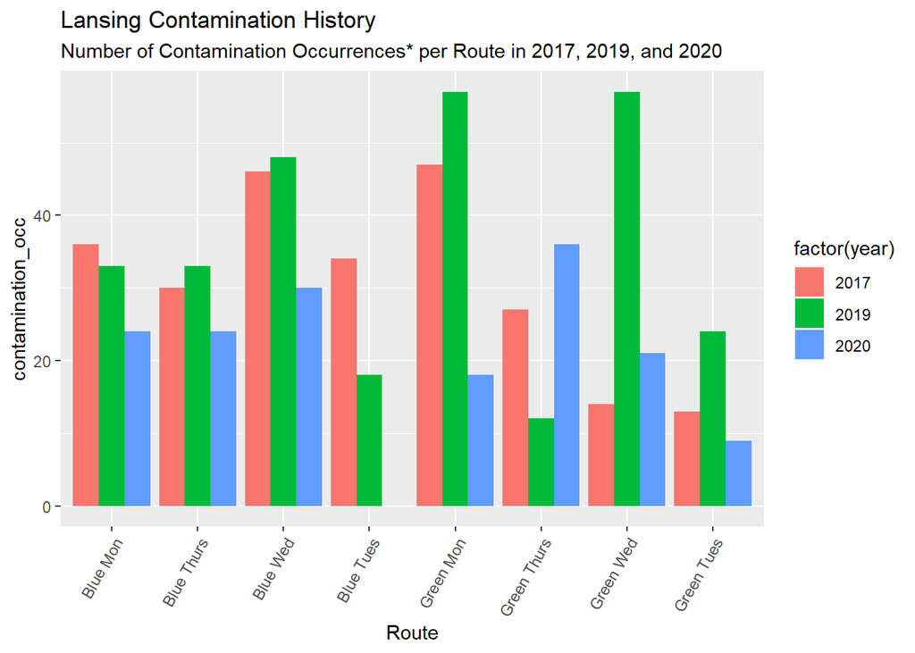

```r
ggplot(contam_hx2, aes(x=Route, y=contamination_occ, fill = factor(year))) +
  geom_col(position = "dodge") +
  scale_x_discrete(labels = c("Blue Mon", "Blue Thurs", "Blue Wed", "Blue Tues", "Green Mon", "Green Thurs", "Green Wed", "Green Tues")) +
  theme(axis.text.x = element_text(angle=60, hjust=1)) +
  labs(title = "Lansing Contamination History", subtitle = "Number of Contamination Occurrences* per Route in 2017, 2019, and 2020")
```

```r
contaminations2017<- contam_hx %>% filter(year == "2017")
#contaminations2017
stats2017 <- contaminations2017 %>%
  summarize(mean=mean(contamination_occ),
            std_dev=sd(contamination_occ),
            n=sum(contamination_occ))
mean2017 <- stats2017 %>% pull(mean)
stats2017
```

```
##     mean  std_dev   n
## 1 30.875 12.78881 247
```

```r
contaminations2019 <- contam_hx %>% filter(year == "2019") %>%
  mutate(estimated_contamination_occ = contamination_occ*3)
#contaminations2019
stats2019 <-  contaminations2019 %>%
  summarize(mean=mean(estimated_contamination_occ),
            std_dev=sd(estimated_contamination_occ),
            n=sum(estimated_contamination_occ))
mean2019 <- stats2019 %>% pull(mean)
stats2019
```

```
##    mean  std_dev   n
## 1 35.25 17.25233 282
```

```r
contaminations2020 <- contam_hx %>% filter(year == "2020") %>%
  mutate(estimated_contamination_occ = contamination_occ*3)
#contaminations2020
stats2020 <-  contaminations2020 %>%
  summarize(mean=mean(estimated_contamination_occ),
            std_dev=sd(estimated_contamination_occ),
            n=sum(estimated_contamination_occ))
stats2020
```

```
##    mean  std_dev   n
## 1 20.25 11.42366 162
```

```r
diff_means <- mean2017-mean2019
```

```r
contam_hx_test <- t.test(contaminations2017$contamination_occ, contaminations2019$estimated_contamination_occ, alternative = "two.sided", mu = diff_means, conf.level = 0.95)
contam_hx_test
```

```
##
##  Welch Two Sample t-test
##
## data:  contaminations2017$contamination_occ and contaminations2019$estimated_contamination_occ
## t = 0, df = 12.909, p-value = 1
## alternative hypothesis: true difference in means is not equal to -4.375
## 95 percent confidence interval:
##  -20.78988  12.03988
## sample estimates:
## mean of x mean of y
##    30.875    35.250
```

# Recycling Situations Hypothesis Tests

Descriptive Survey Data 6% of contaminated recyclables in 2019 audit was due to wishful recycling.

According to resident feedback survey 8.6% of residents will wishful recycle and 38.36% of residents will properly dispose if they are unsure if an item is not recyclable

National inbound contamination rate is 16.9%

```r
#t-test
rc_groups <- rc_situations %>%
  select(unsure_item_in_trash, unsure_item_in_recycling) %>%
  mutate('proper_disp' = unsure_item_in_trash == "Extremely likely" | unsure_item_in_trash == "Somewhat likely", 'wishful_rc' = unsure_item_in_recycling == "Extremely likely" | unsure_item_in_recycling == "Somewhat likely")
#%>% filter(unsure_item_in_trash == "Extremely likely" | unsure_item_in_trash == "Somewhat likely", unsure_item_in_recycling == "Extremely likely" | unsure_item_in_recycling == "Somewhat likely")

rc_groups$proper_disp <- as.character(rc_groups$proper_disp)
rc_groups$wishful_rc <- as.character(rc_groups$wishful_rc)

#rc_groups
```

```r
rc_counts <- rc_groups %>%
  group_by(proper_disp, wishful_rc) %>%
  summarize(n = n())
rc_counts
```

```
## # A tibble: 4 x 3
## # Groups:   proper_disp [2]
##   proper_disp wishful_rc     n
##   <chr>       <chr>      <int>
## 1 FALSE       FALSE        135
## 2 FALSE       TRUE          15
## 3 TRUE        FALSE        325
## 4 TRUE        TRUE          65
```

```r
array <- data.matrix(rc_counts)
(x <- margin.table(array, c(1, 2)) )
```

```
##      proper_disp wishful_rc   n
## [1,]           1          1 135
## [2,]           1          2  15
## [3,]           2          1 325
## [4,]           2          2  65
```

pd false and wrc false = neither trashing or recycling an item when unsure about it pd false and wrc true = recycling an item when unsure about it pd true and wrc false = trashing an item when unsure about it pd true and wrc false = both trashing and recycling an item when unsure about it.

**Question 1: is the proportion of wishful recyclers different than national inbound contamination rate of 16.9%**

Null Hypothesis: proportion of wishful recyclers = 16.9%

Alternative Hypothesis: proportion of wishful recyclers != 16.9%

```r
q1_ttest <- t.test(x = (rc_groups$wishful_rc == "Extremely likeley" | rc_groups$wishful_rc == "Somewhat likeley"), alternative = "two.sided", mu = .169, conf.level = 0.95)
q1_ttest
```

```
##
##  One Sample t-test
##
## data:  (rc_groups$wishful_rc == "Extremely likeley" | rc_groups$wishful_rc == "Somewhat likeley")
## t = -Inf, df = 539, p-value < 2.2e-16
## alternative hypothesis: true mean is not equal to 0.169
## 95 percent confidence interval:
##  NaN NaN
## sample estimates:
## mean of x
##         0
```

Calculate observed proportion

```r
obs_prop_q1 <- rc_groups %>%
  specify(response = wishful_rc, success = "TRUE") %>%
  calculate(stat = "prop") %>%
  pull(stat)
obs_prop_q1
```

```
## [1] 0.1481481
```

```r
null_prop <- .169
```

Create Simulation **With Replacement**

```r
null_dist_q1 <- rc_groups %>%
  specify(response = wishful_rc, success = "TRUE") %>%
  generate(reps = 1000, type="bootstrap") %>%
  calculate(stat="prop")
#null_dist_q1
```

Confidence interval

```r
percentile_ci_q1 <- null_dist_q1 %>% get_confidence_interval(level=00.95, type="percentile")
percentile_ci_q1
```

```
## # A tibble: 1 x 2
##   lower_ci upper_ci
##      <dbl>    <dbl>
## 1    0.117    0.180
```

Visualize Simulation

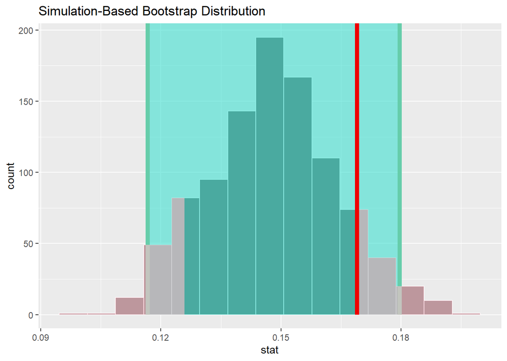

```r
null_dist_q1 %>% visualize() +
  shade_confidence_interval(endpoints = percentile_ci_q1) +
  shade_p_value(obs_stat = null_prop, direction = "both", fill = "pink")
```

```r
q1_sim_pvalue <- get_p_value(null_dist_q1, obs_stat=null_prop, direction="both")
q1_sim_pvalue
```

```
## # A tibble: 1 x 1
##   p_value
##     <dbl>
## 1   0.172
```

**Question2: is there a significant difference in the percentage of wishful recyclers and proper disposers?**

Null Hypothesis: proportion of wishful recyclers = proportion of proper disposers

Alternative Hypothesis: proportion of wishful recyclers != proportion of proper disposers

```r
q2_obs_stat <- rc_groups %>%
  specify(response = proper_disp, explanatory = wishful_rc, success = "TRUE") %>%
  calculate(stat = "diff in props", order = c("TRUE", "FALSE")) %>%
  pull(stat)
q2_obs_stat
```

```
## [1] 0.1059783
```

Q2 t-test

```r
q2_ttest <- t.test(x = (rc_groups$wishful_rc == "Extremely likeley" | rc_groups$wishful_rc == "Somewhat likeley"), y = (rc_groups$proper_disp == "Extremely likeley" | rc_groups$proper_disp == "Somewhat likeley"), alternative = "two.sided", mu = q2_obs_stat, conf.level = 0.95)
q2_ttest
```

```
##
##  Welch Two Sample t-test
##
## data:  (rc_groups$wishful_rc == "Extremely likeley" | rc_groups$wishful_rc == "Somewhat likeley") and (rc_groups$proper_disp == "Extremely likeley" | rc_groups$proper_disp == "Somewhat likeley")
## t = -Inf, df = NaN, p-value = NA
## alternative hypothesis: true difference in means is not equal to 0.1059783
## 95 percent confidence interval:
##  NaN NaN
## sample estimates:
## mean of x mean of y
##         0         0
```

Create Simulation **with Replacement**

variables are independent of each other

```r
q2_diff_prop <- rc_groups %>%
  specify(proper_disp ~ wishful_rc, success = "TRUE") %>%
  calculate(stat = "diff in props", order = c("TRUE", "FALSE"))
q2_diff_prop
```

```
## # A tibble: 1 x 1
##    stat
##   <dbl>
## 1 0.106
```

```r
null_dist_q2 <- rc_groups %>%
  specify(formula = proper_disp ~ wishful_rc, success = "TRUE") %>%
  hypothesize(null = "independence") %>%
  generate(reps = 1000, type = "bootstrap") %>%
  calculate(stat = "diff in props", order = c("TRUE", "FALSE"))
#null_dist_q2
```

Confidence interval

```r
percentile_ci_q2 <- null_dist_q2 %>% get_confidence_interval(level=00.95, type="percentile")
percentile_ci_q2
```

```
## # A tibble: 1 x 2
##   lower_ci upper_ci
##      <dbl>    <dbl>
## 1   0.0158    0.201
```

Visualize Simulation

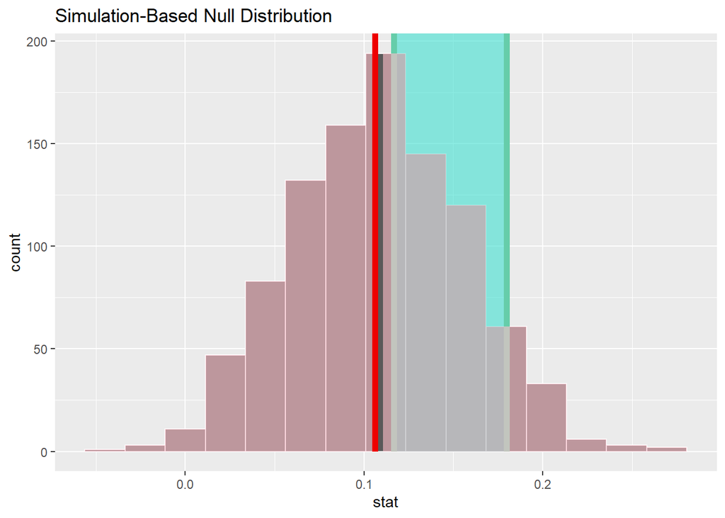

```r
null_dist_q2 %>% visualize() +
  shade_confidence_interval(endpoints = percentile_ci_q1) +
  shade_p_value(q2_diff_prop, direction = "both")
```

```r
q2_sim_pvalue <- get_p_value(null_dist_q2, obs_stat=q2_diff_prop, direction="both")
q2_sim_pvalue
```

```
## # A tibble: 1 x 1
##   p_value
##     <dbl>
## 1   0.962
```

“To obtain more precise population estimates, one should minimize samplinlg error, which is measured by standard error. The size of standard error is related to the sample size and variation in the population. As a general guide, to halve the standard error, the sample size must be quadrupled.”

referenced https://www.theanalysisfactor.com/interpret-width-of-confidence-interval/#:~:text=The%20greater%20the%20confidence%20level,by%20the%20standard%20error%20statistic.

**Sampled without replacement**

variables are dependent on each other

```r
set.seed(538)
sample <- c(floor(runif(50, 0, 540)))
sample
```

```
##  [1]   1 341 506 247 514 258 512 495  10 430 150 300 310 400 332 401 481 205 219
## [20] 501 284  31 369 130 296   0 319 282 431 284 454  87 116  38 309 133 481 512
## [39] 164 266 222 107 162  12 137 510 105  28  35 135
```

```r
q2_sample2 <- rc_groups %>% slice(sample)
```

```r
q2_sample_shuffled <- q2_sample2 %>%
  mutate(wishful_rc = sample(wishful_rc))
#q2_sample_shuffled
```

```r
#wishful stats shuffled
n_proper_disp <- q2_sample_shuffled %>%
  filter(proper_disp == "TRUE", wishful_rc == "FALSE") %>%
  nrow()
n_wishful_rc <- q2_sample_shuffled %>%
  filter(proper_disp == "FALSE", wishful_rc == "TRUE") %>%
  nrow()
prop_wishful_rc <- n_wishful_rc / (n_wishful_rc + n_proper_disp)
prop_wishful_rc
```

```
## [1] 0.09677419
```

```r
#non wishful stats shuffled
n_notproper_disp <- q2_sample_shuffled %>%
  filter(proper_disp == "FALSE", wishful_rc == "FALSE") %>%
  nrow()
n_notwishful_rc <- q2_sample_shuffled %>%
  filter(proper_disp == "TRUE", wishful_rc == "FALSE") %>%
  nrow()
prop_nonwishful_rc <- n_notwishful_rc / (n_notwishful_rc + n_notproper_disp)
prop_nonwishful_rc
```

```
## [1] 0.6666667
```

```r
#diff props shuffled
diff_prop <- round(prop_wishful_rc - prop_nonwishful_rc, 3)
diff_prop
```

```
## [1] -0.57
```

```r
#round props post difference
prop_wishful_rc <- round(prop_wishful_rc, 3)
prop_nonwishful_rc <- round(prop_nonwishful_rc, 3)
```

```r
#observed diff in props
obs_diff_prop <- rc_groups %>%
  specify(proper_disp ~ wishful_rc, success = "TRUE") %>%
  calculate(stat = "diff in props", order = c("TRUE", "FALSE"))
obs_diff_prop
```

```
## # A tibble: 1 x 1
##    stat
##   <dbl>
## 1 0.106
```

```r
#hypothesize independence of response from explanatory variable (proper disposal is independent of wishful recycling)

null_distribution <- rc_groups %>%
  specify(formula = proper_disp ~ wishful_rc, success = "TRUE") %>%
  hypothesize(null = "independence") %>%
  generate(reps = 1000, type = "permute") %>%
  calculate(stat = "diff in props", order = c("TRUE", "FALSE"))
#null_distribution
```

```r
obs_diff_prop <- rc_groups %>%
  specify(proper_disp ~ wishful_rc, success = "TRUE") %>%
  calculate(stat = "diff in props", order = c("TRUE", "FALSE"))
obs_diff_prop #observed difference
```

```
## # A tibble: 1 x 1
##    stat
##   <dbl>
## 1 0.106
```

```r
percentile_ci_q3 <- null_distribution %>% get_confidence_interval(level=00.95, type="percentile")
percentile_ci_q3
```

```
## # A tibble: 1 x 2
##   lower_ci upper_ci
##      <dbl>    <dbl>
## 1  -0.0995    0.106
```

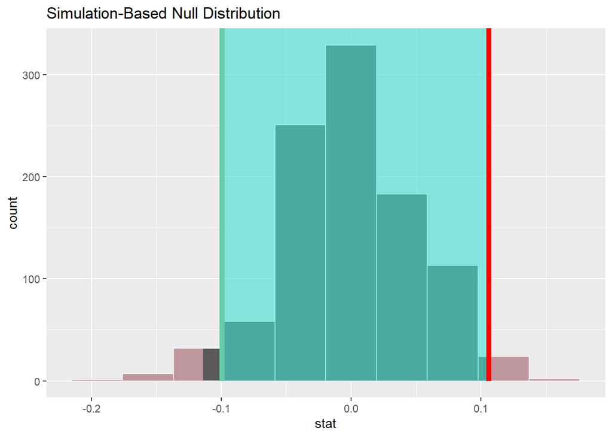

```r
visualize(null_distribution, bins = 10) +
  shade_confidence_interval(endpoints = percentile_ci_q3) +
  shade_p_value(obs_stat = obs_diff_prop, direction = "both", color = "red")
```

```r
p_value <- null_distribution %>%
  get_p_value(obs_stat = obs_diff_prop, direction = "both")
#%>% mutate(p_value = round(p_value, 3))
p_value
```

```
## # A tibble: 1 x 1
##   p_value
##     <dbl>
## 1   0.052
```

```r
null_distribution_extra <- q2_sample_shuffled %>%
  specify(formula = proper_disp ~ wishful_rc, success = "TRUE") %>%
  hypothesize(null = "independence") %>%
  generate(reps = 5000, type = "permute") %>%
  calculate(stat = "diff in props", order = c("TRUE", "FALSE"))
#null_distribution_extra
```

```r
null_distribution_extra %>% get_p_value(obs_stat = obs_diff_prop, direction = "both")
```

```
## # A tibble: 1 x 1
##   p_value
##     <dbl>
## 1   0.451
```

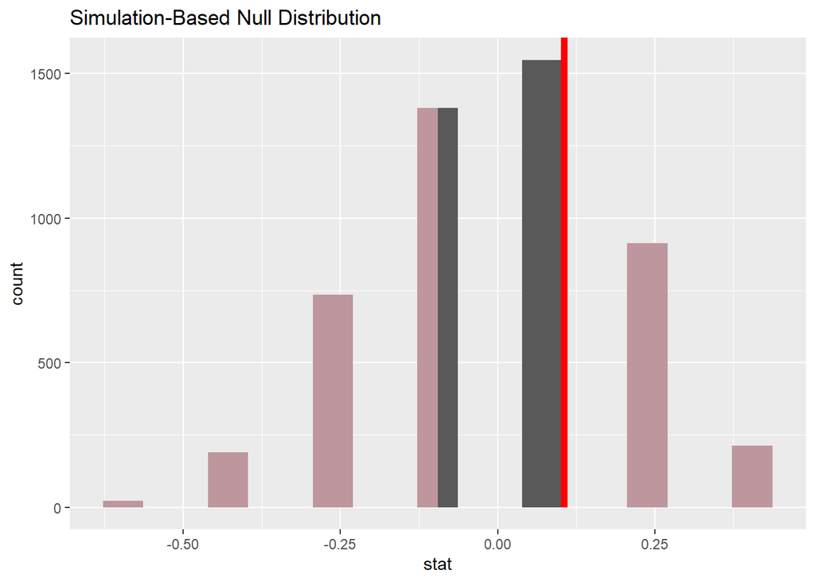

```r
visualize(null_distribution_extra, bins = 10) +
  shade_p_value(obs_stat = obs_diff_prop, direction = "both", color = "red")
```

# t-Test Interpretation

we do not have evidence to reject the null hypothesis in favor of the alternative hypothesis.

null hypothesis: there is no difference in the proper disposal between wishful recyclers and non wishful recyclers.

alt hypothesis: there is a difference in the proper disposal between wishful recyclers and non wishful recyclers.

other alt hypothesis: given an understanding of how the world works, there is not enough evidence that proper disposers are wishful recyclers deferentially less or more often than non wishful recyclers.

# Recycling Situations Type I and II Errors

referenced https://www.statmethods.net/stats/power.html and SI544 Disc nb 11

pvalues (in each hypothesis test) > .05

the probability of getting a type I (reject the null hypothesis when it is in fact true) error is the level of significance (alpha = 0.05)

```r
effect_size <- cohen.ES(test = "r", size = "medium")
effect_size
```

```
##
##      Conventional effect size from Cohen (1982)
##
##            test = r
##            size = medium
##     effect.size = 0.3
```

```r
power <- pwr.t.test(n = 540, d = 0.3 , type = "two.sample")
power
```

```
##
##      Two-sample t test power calculation
##
##               n = 540
##               d = 0.3
##       sig.level = 0.05
##           power = 0.9984873
##     alternative = two.sided
##
## NOTE: n is number in *each* group
```